# Trait Ordination Plant Community Analysis

1. traits
   1. above- and belowground
      1. height & SLA
   2. acquisitive vs. conservative resource-use strategies
      1. rooting depth
   3. collaborative vs. individual resource-use strategies
      1. fine root proportion
      2. thickness of roots

Goal: Examine how traits shift in community compositional (ordinational) space, placing each trait on an axis.

Author: Caryn D. Iwanaga

Updated: 01/24/2025

## Libraries

```r
library(tidyverse)
```

```r
library(dplyr)
library(ggplot2)
library(httr) # read out Dropbox folders
library(vegan)
```

## Read in Data

```r
cover.dat.labels <- read.csv("https://www.dropbox.com/scl/fi/up8nnzkcpchsr45f8cm92/Compost_Cover_LongClean.csv?rlkey=z2tvaj8t6khadef7ydz782zka&st=qwef9ys0&dl=1") %>%
  mutate(
    nut_trt = factor(ifelse(nut_trt =="C", "+compost", ifelse(nut_trt =="F", "+N fertilizer", ifelse(nut_trt =="N", "control", NA))), levels = c("control", "+N fertilizer", "+compost")),
    ppt_trt = ifelse(ppt_trt == "D", "dry", ifelse(ppt_trt == "XC", "control", ifelse(ppt_trt == "W", "wet", NA))))
```

## Make site x species matrix

1. Calculate relative abundances of species for each site
   1. confused how to aggregate abundances because even grouping by plotid (nut_trt and ppt_trt), year, species, and grazing history (block 1&2 – high, block 3&4 – low) and averaged, the sd are as high as 45.96!
      1. proceeded with these high sd to see what happens (ask Lauren)

```r
site.df <-
  cover.dat.labels[, c(1:7, 18:19)] %>% #subset columns
  mutate(
    grazing_hist = ifelse(block == 1 | block == 2, "high", ifelse(block == 3 | block == 4, "low", NA))
  ) %>% # separate by block (grazing intensities)
  group_by(nut_trt, ppt_trt, yr, code4, grazing_hist) %>% # make each code unique -- one value for species abundance for each trt
  summarise(
    # pct_cover,
    abundance = mean(pct_cover)
    # sd = sd(pct_cover)
  )
```

[output not shown]

```r
matrix0 <- spread(
  site.df,
  code4,
  abundance,
  fill = 0)

# make rownames ----
rownames(matrix0) <- paste(matrix0$nut_trt, matrix0$ppt_trt, matrix0$yr, matrix0$grazing_hist, sep = "_")
# delete columns ----
matrix <- matrix0[, c(5:79)]

# relativize data with Bray-Curtis dissimilarity
matrix.bray <- decostand(matrix, "total")
rownames(matrix.bray) <- rownames(matrix0)
```

## Run NMDS

Rules of thumb:

- < 0.05 is **excellent**
- 0.05-0.1 is **good**
- 0.1-0.2 is **fair**
- 0.2-0.3 **is cause for concern…**
- > 0.3 **is poor, random**

### All years

Stress: *fair*

[output not shown]

Grouping by year and grazing history had most significant clustering shown.

##### metaMDS()

```r
nmds.comp <- metaMDS(matrix.bray, k=2, trymax = 25)
```

```
## *** Best solution repeated 1 times
```

```r
nmds.comp # pretty not great stress
```

```
##
## Call:
## metaMDS(comm = matrix.bray, k = 2, trymax = 25)
##
## global Multidimensional Scaling using monoMDS
##
## Data:     matrix.bray
## Distance: bray
##
## Dimensions: 2
## Stress:     0.1970631
## Stress type 1, weak ties
## Best solution was repeated 1 time in 21 tries
## The best solution was from try 19 (random start)
## Scaling: centring, PC rotation, halfchange scaling
## Species: expanded scores based on 'matrix.bray'
```

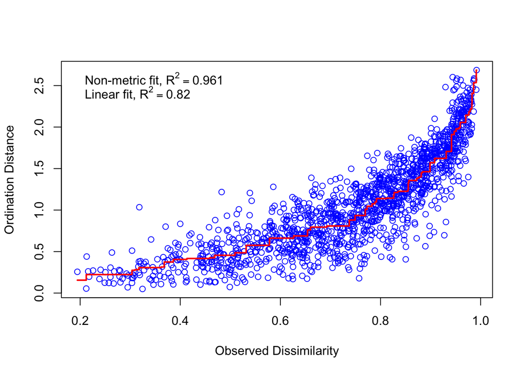

```r
stressplot(nmds.comp)
```

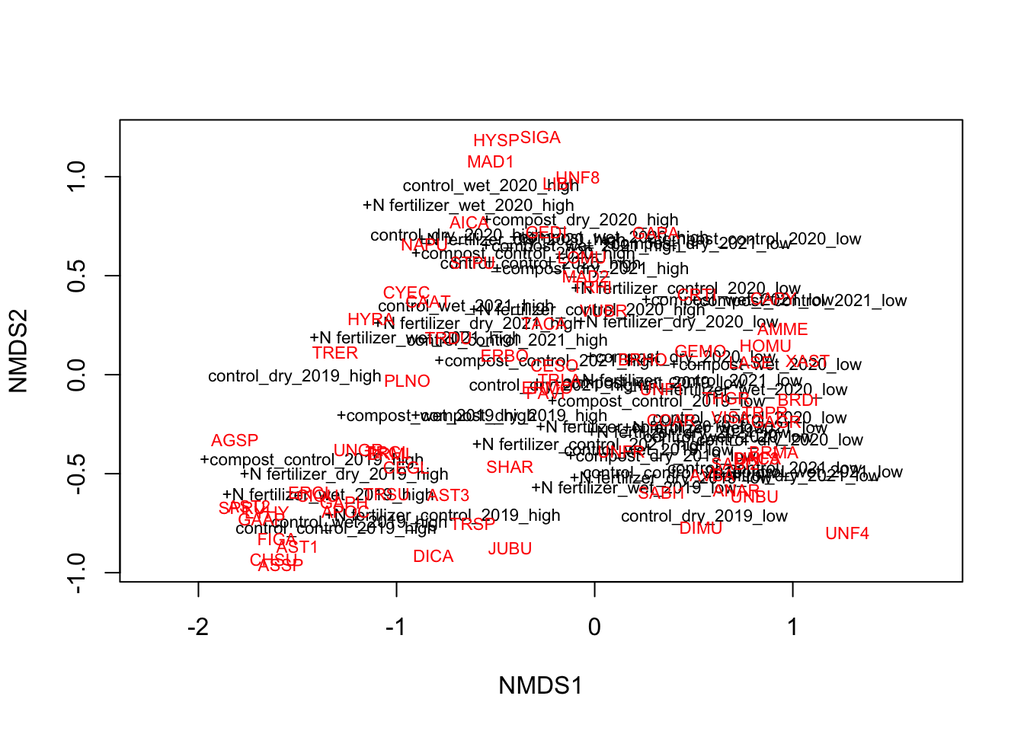

```r
plot(nmds.comp, type="t")
```

```r
nmds1 <- as.data.frame(scores(nmds.comp, choices=c(1), display=c("sites"))) %>%
  mutate(matrix0[, c(0:4)])
nmds2 <- as.data.frame(scores(nmds.comp, choices=c(2), display=c("sites")))

nmds_dat <- cbind(nmds1, nmds2) %>%
  select(nut_trt:grazing_hist, NMDS1, NMDS2)
```

##### plot

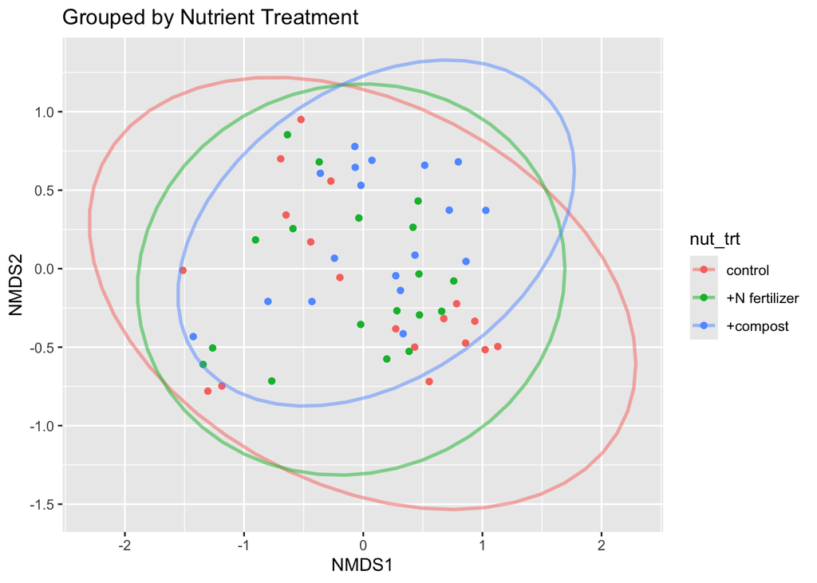

```r
ggplot(nmds_dat, aes(NMDS1, NMDS2,  color = nut_trt)) +
  geom_point() +
  stat_ellipse(type = "norm", size = 1, alpha = 0.5) + # Ellipses for each group
  labs(title = "Grouped by Nutrient Treatment")
```

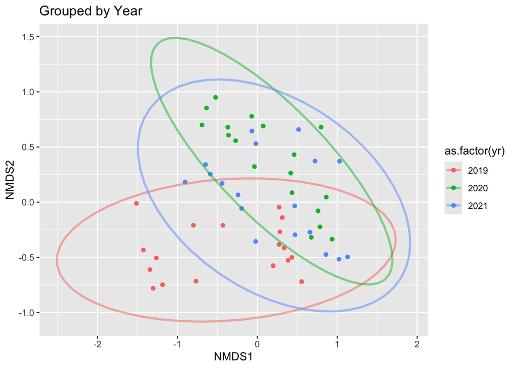

```r
ggplot(nmds_dat, aes(NMDS1, NMDS2,  color = as.factor(yr))) +
  geom_point() +
  stat_ellipse(type = "norm", size = 1, alpha = 0.5) + # Ellipses for each group
  labs(title = "Grouped by Year")
```

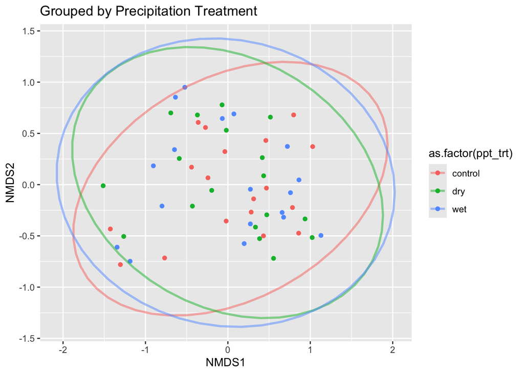

```r
ggplot(nmds_dat, aes(NMDS1, NMDS2,  color = as.factor(ppt_trt))) +
  geom_point() +
  stat_ellipse(type = "norm", size = 1, alpha = 0.5) + # Ellipses for each group
  labs(title = "Grouped by Precipitation Treatment")
```

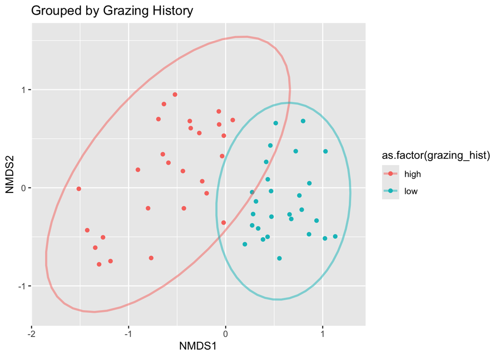

```r
ggplot(nmds_dat, aes(NMDS1, NMDS2,  color = as.factor(grazing_hist))) +
  geom_point() +
  stat_ellipse(type = "norm", size = 1, alpha = 0.5) + # Ellipses for each group
  labs(title = "Grouped by Grazing History")
```

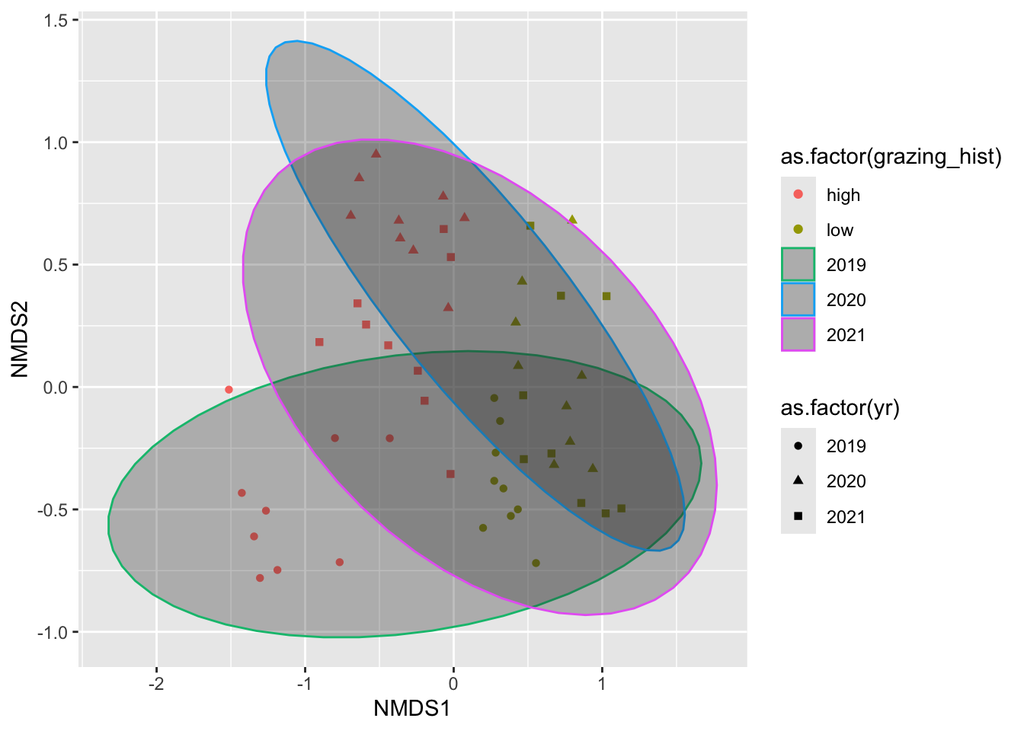

```r
ggplot(nmds_dat, aes(NMDS1, NMDS2,  color = as.factor(grazing_hist), shape = as.factor(yr))) +
  geom_point() +
  stat_ellipse(aes(color = as.factor(yr)),
                 geom = "polygon", alpha = 0.3)
```

```r
  labs(title = "Grouped by Grazing History & Year")
```

```
## $title
## [1] "Grouped by Grazing History & Year"
##
## attr(,"class")
## [1] "labels"
```

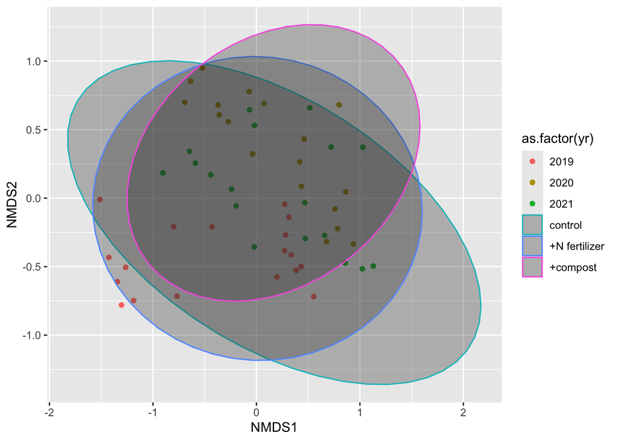

```r
ggplot(nmds_dat, aes(NMDS1, NMDS2,  color = as.factor(yr))) +
  geom_point() +
  stat_ellipse(aes(color = as.factor(nut_trt)),

                 geom = "polygon", alpha = 0.3)
```

```r
  labs(title = "Grouped by Grazing History & Year")
```

```
## $title
## [1] "Grouped by Grazing History & Year"
##
## attr(,"class")
## [1] "labels"
```

Make each individual year NMDS to see if there’s better stress

### 2019

#### data wrangling

```r
# relativize data with Bray-Curtis dissimilarity
matrix.2019 <- matrix0 %>%
  filter(yr == 2019)

row.2019 <- paste(matrix.2019$nut_trt, matrix.2019$ppt_trt, matrix.2019$yr, matrix.2019$grazing_hist, sep = "_")

matrix.2019 <- matrix.2019[, c(5:79)]

rownames(matrix.2019) <- row.2019
matrix.bray.2019 <- decostand(matrix.2019, "total")
```

#### nmds 2019

```
0.0560178
```

##### metaMDS()

```r
nmds.2019 <- metaMDS(matrix.bray.2019, k=2, trymax = 25)
```

```
## *** Best solution repeated 1 times
```

```r
nmds.2019 # pretty not great stress
```

```
##
## Call:
## metaMDS(comm = matrix.bray.2019, k = 2, trymax = 25)
##
## global Multidimensional Scaling using monoMDS
##
## Data:     matrix.bray.2019
## Distance: bray
##
## Dimensions: 2
## Stress:     0.0560178
## Stress type 1, weak ties
## Best solution was repeated 1 time in 20 tries
## The best solution was from try 0 (metric scaling or null solution)
## Scaling: centring, PC rotation, halfchange scaling
## Species: expanded scores based on 'matrix.bray.2019'
```

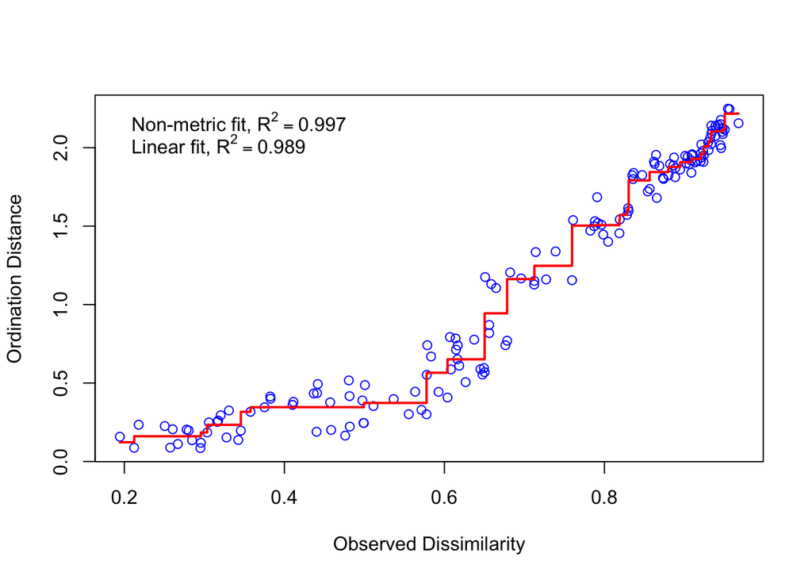

```r
stressplot(nmds.2019)
```

```r
# plot(nmds.2019, type="t")

nmds1.2019 <- as.data.frame(scores(nmds.2019, choices=c(1), display=c("sites"))) %>%
  mutate(
    nut_trt = sapply(strsplit(rownames(matrix.2019), "_"), `[`, 1),
    ppt_trt = sapply(strsplit(rownames(matrix.2019), "_"), `[`, 2),
    yr = sapply(strsplit(rownames(matrix.2019), "_"), `[`, 3),
    grazing_hist = sapply(strsplit(rownames(matrix.2019), "_"), `[`, 4)
  )
nmds2.2019 <- as.data.frame(scores(nmds.2019, choices=c(2), display=c("sites")))

nmds_2019_dat <- cbind(nmds1.2019, nmds2.2019) %>%
  select(nut_trt:grazing_hist, NMDS1, NMDS2)
```

##### plot

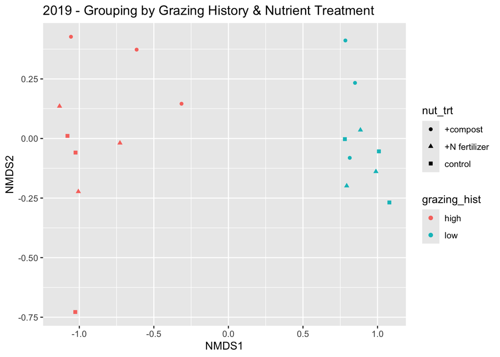

```r
ggplot(nmds_2019_dat, aes(NMDS1, NMDS2,  color = grazing_hist, shape = nut_trt)) +
  geom_point() +
  labs(title = "2019 - Grouping by Grazing History & Nutrient Treatment")
```

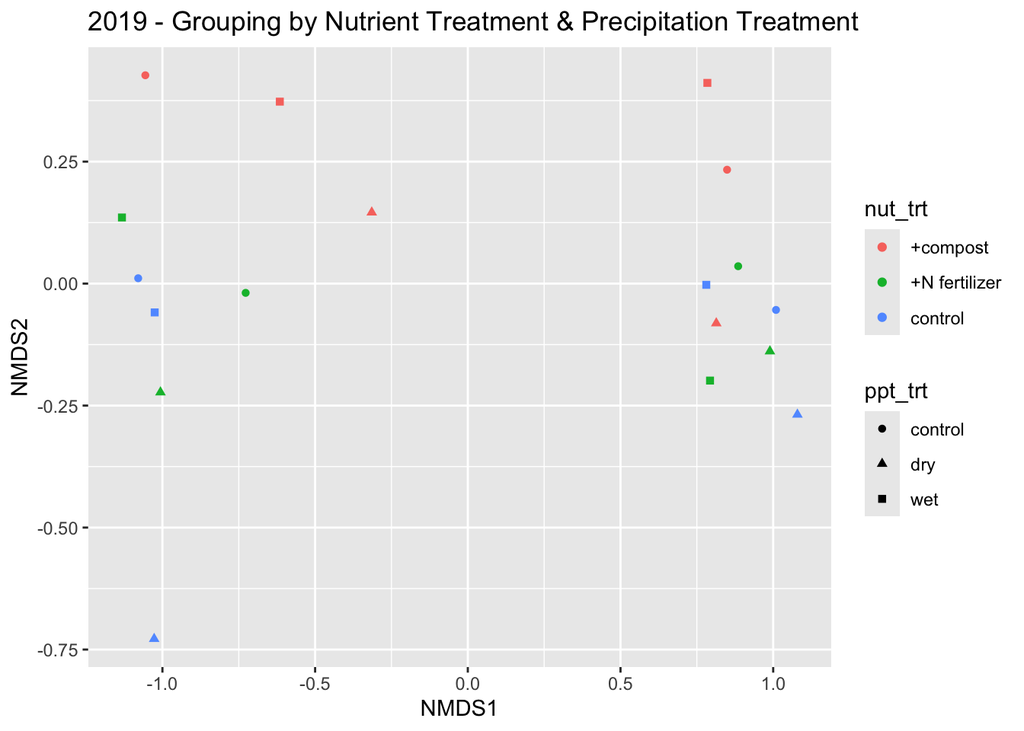

```r
ggplot(nmds_2019_dat, aes(NMDS1, NMDS2,  color = nut_trt, shape = ppt_trt)) +
  geom_point() +
  labs(title = "2019 - Grouping by Nutrient Treatment & Precipitation Treatment")
```

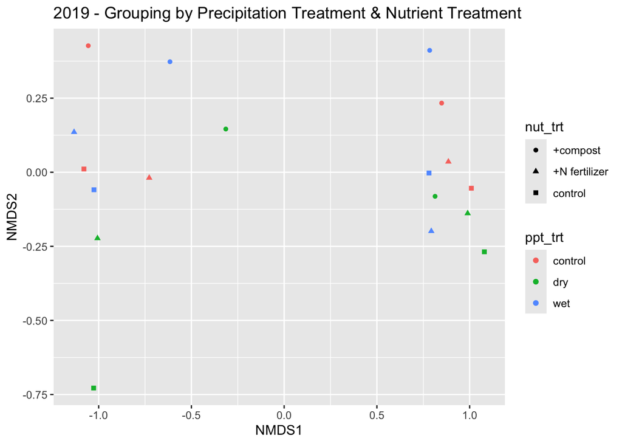

```r
ggplot(nmds_2019_dat, aes(NMDS1, NMDS2,  color = ppt_trt, shape = nut_trt)) +
  geom_point() +
  labs(title = "2019 - Grouping by Precipitation Treatment & Nutrient Treatment")
```